# VIQ - Laboratorio 4

2021-04-22

### Obiettivi

1. Manipolare data set
2. Grafici essenziali

### Strumento

R ed RStudio, in particolare la libreria tidyverse:

```r
library(tidyverse)
library(magrittr)
library(readxl)
```

### Dataset

Utilizziamo il dataset pubblico sui dati di occupazione ISTAT con periodo di riferimento GENNAIO-FEBBRAIO 2021, pubblicati in data 06 APRILE 2021:

https://www.istat.it/it/archivio/256254

Scaricare il file `.xls` corrispondente al link **SERIE STORICHE**.

```r
url = 'https://www.istat.it/it/files//2021/04/202102_serie-storiche.xls'
file = "202102_serie-storiche.xls"
if( ! file.exists(file) ){
  download.file(url,file,mode="wb")
}
```

## Lettura

Leggere dal primo foglio (`Tab1`) i principali indicatori (destagionalizzati). Attenzione alle righe iniziali che contengono descrizioni e non dati.

Suggerimenti:

- trattandosi di un file `.xls`, usare la funzione `read_xls()` (analoga alla funzione `read_xlsx()`)
- specificare il nome (o il numero del foglio)
- passare come terzo paramentro
  - la porzione di dataset che si vuole analizzare, indicando le coordinate delle celle agli estremi della diagonale principale, tipo `"B2:E10"`
  - le righe iniziali da scartare

```r
## DA COMPLETARE
d_occupazione <- read_xls(file, sheet = 1, skip=7)
```

```
* `` -> ...2
* `` -> ...3
* `` -> ...4
* `` -> ...5
* `` -> ...6
* ...
```

```r
d_occupazione
```

| Maschi e Femmine | ...2 | ...3 | ...4 | ...5 | ...6 | Maschi | ...8 | ...9 | ...10 | ...11 | Femmine | ...13 | ...14 | ...15 | ...16 |
| --- | --- | --- | --- | --- | --- | --- | --- | --- | --- | --- | --- | --- | --- | --- | --- |
| 2004 | Gennaio | 62.51241 | 57.26618 | 8.318213 | 23.02467 | 2004 | Gennaio | 74.23701 | 69.49558 | 6.325251 | 2004 | Gennaio | 50.89549 | 45.14910 | 11.225915 |
| NA | Febbraio | 62.46365 | 57.38719 | 8.059644 | 22.43787 | NA | Febbraio | 74.26258 | 69.55450 | 6.274963 | NA | Febbraio | 50.77213 | 45.33064 | 10.669832 |
| NA | Marzo | 62.80778 | 57.60631 | 8.194947 | 23.13517 | NA | Marzo | 74.63560 | 69.73115 | 6.492869 | NA | Marzo | 51.08715 | 45.59136 | 10.680558 |
| NA | Aprile | 62.29403 | 57.17253 | 8.147783 | 23.89849 | NA | Aprile | 74.17994 | 69.45490 | 6.296168 | NA | Aprile | 50.51514 | 45.00077 | 10.868379 |
| NA | Maggio | 62.75064 | 57.56755 | 8.166989 | 23.99800 | NA | Maggio | 74.61510 | 69.69409 | 6.500960 | NA | Maggio | 50.99217 | 45.54935 | 10.607540 |
| NA | Giugno | 62.78453 | 57.77809 | 7.910018 | 23.47004 | NA | Giugno | 74.58227 | 69.68460 | 6.512582 | NA | Giugno | 51.09048 | 45.97624 | 9.951128 |
| NA | Luglio | 62.67282 | 57.67071 | 7.898022 | 22.85308 | NA | Luglio | 74.63432 | 69.85945 | 6.320161 | NA | Luglio | 50.81518 | 45.58783 | 10.215034 |
| NA | Agosto | 62.33057 | 57.48012 | 7.711563 | 22.26782 | NA | Agosto | 74.20529 | 69.62153 | 6.108206 | NA | Agosto | 50.55749 | 45.44263 | 10.065492 |
| NA | Settembre | 62.56192 | 57.49860 | 8.027493 | 23.41267 | NA | Settembre | 74.35497 | 69.49592 | 6.469198 | NA | Settembre | 50.86789 | 45.60203 | 10.305232 |
| NA | Ottobre | 62.66529 | 57.63153 | 7.949990 | 23.85504 | NA | Ottobre | 74.45490 | 69.74783 | 6.242109 | NA | Ottobre | 50.97312 | 45.61538 | 10.448305 |

[output cut: 196 more lines]

Le colonne sono a gruppi di 6 e rappresentano rispettivamente *Tutti*, *Maschi* e *Femmine*.

In ciascun gruppo le colonne rappresentano:

- Anno di riferimento
- Mese di riferimento
- Tasso di attività
- Tasso di occupazione
- Tasso di disoccupazione generale
- Tasso di disoccupazione giovanile (15-24 anni) (solo per *Tutti*)

I nomi che ci si attende dovrebbero essere quelli costruiti nel seguente chunk

```r
colonne <- rep(c("tutti","m","f"),each=6) %>%  ## ripete 6 volte ciascun prefisso
          paste(                              ## concatenato con
                rep(c("anno","mese",          ## ripete 3 volte le sei informazioni
                      "attivita","occupazione",
                      "disoccupazione",
                      "disoccupazione.giovani"),3),
                sep="_") # separatore di concatenazione
colonne <- colonne[c(-12,-18)]
colonne
```

```
 [1] "tutti_anno"                   "tutti_mese"                   "tutti_attivita"
 [4] "tutti_occupazione"            "tutti_disoccupazione"         "tutti_disoccupazione.giovani"
 [7] "m_anno"                       "m_mese"                       "m_attivita"
[10] "m_occupazione"                "m_disoccupazione"             "f_anno"
[13] "f_mese"                       "f_attivita"                   "f_occupazione"
[16] "f_disoccupazione"
```

Verificare (e porre rimedio) ai seguenti problemi:

- i nomi delle colonne sono corretti e significativi?

```r
## DA COMPLETARE
names(d_occupazione) <- colonne
d_occupazione
```

| tutti_anno | tutti_mese | tutti_attivita | tutti_occupazione | tutti_disoccupazione | tutti_disoccupazione.giovani | m_anno | m_mese | m_attivita | m_occupazione | m_disoccupazione | f_anno | f_mese | f_attivita | f_occupazione | f_disoccupazione |
| --- | --- | --- | --- | --- | --- | --- | --- | --- | --- | --- | --- | --- | --- | --- | --- |
| 2004 | Gennaio | 62.51241 | 57.26618 | 8.318213 | 23.02467 | 2004 | Gennaio | 74.23701 | 69.49558 | 6.325251 | 2004 | Gennaio | 50.89549 | 45.14910 | 11.225915 |
| NA | Febbraio | 62.46365 | 57.38719 | 8.059644 | 22.43787 | NA | Febbraio | 74.26258 | 69.55450 | 6.274963 | NA | Febbraio | 50.77213 | 45.33064 | 10.669832 |
| NA | Marzo | 62.80778 | 57.60631 | 8.194947 | 23.13517 | NA | Marzo | 74.63560 | 69.73115 | 6.492869 | NA | Marzo | 51.08715 | 45.59136 | 10.680558 |
| NA | Aprile | 62.29403 | 57.17253 | 8.147783 | 23.89849 | NA | Aprile | 74.17994 | 69.45490 | 6.296168 | NA | Aprile | 50.51514 | 45.00077 | 10.868379 |
| NA | Maggio | 62.75064 | 57.56755 | 8.166989 | 23.99800 | NA | Maggio | 74.61510 | 69.69409 | 6.500960 | NA | Maggio | 50.99217 | 45.54935 | 10.607540 |
| NA | Giugno | 62.78453 | 57.77809 | 7.910018 | 23.47004 | NA | Giugno | 74.58227 | 69.68460 | 6.512582 | NA | Giugno | 51.09048 | 45.97624 | 9.951128 |
| NA | Luglio | 62.67282 | 57.67071 | 7.898022 | 22.85308 | NA | Luglio | 74.63432 | 69.85945 | 6.320161 | NA | Luglio | 50.81518 | 45.58783 | 10.215034 |
| NA | Agosto | 62.33057 | 57.48012 | 7.711563 | 22.26782 | NA | Agosto | 74.20529 | 69.62153 | 6.108206 | NA | Agosto | 50.55749 | 45.44263 | 10.065492 |
| NA | Settembre | 62.56192 | 57.49860 | 8.027493 | 23.41267 | NA | Settembre | 74.35497 | 69.49592 | 6.469198 | NA | Settembre | 50.86789 | 45.60203 | 10.305232 |
| NA | Ottobre | 62.66529 | 57.63153 | 7.949990 | 23.85504 | NA | Ottobre | 74.45490 | 69.74783 | 6.242109 | NA | Ottobre | 50.97312 | 45.61538 | 10.448305 |

[output cut: 196 more lines]

- ci sono colonne inutili (vuote o ripetute) ?

```r
## DA COMPLETARE
d_occupazione %<>% select(-m_anno, -m_mese, -f_anno, -f_mese) %<>% rename(anno = tutti_anno, mese = tutti_mese)
```

## Riassettare i dati (tidy)

#### Osservazione

La funzione `fill()` permette di specificare delle colonne i cui valori `NA` vengono *riempiti* con l’ultimo valore precedente valido.

```r
dfill = data.frame(caso=c("A",NA,NA,"B",NA),
                   valore=c(14,13,5,4,12))
dfill
```

| caso | valore |
| --- | --- |
| A | 14 |
| NA | 13 |
| NA | 5 |
| B | 4 |
| NA | 12 |

```r
dfill %>% fill(caso)
```

| caso | valore |
| --- | --- |
| A | 14 |
| A | 13 |
| A | 5 |
| B | 4 |
| B | 12 |

- ci sono delle colonne incomplete da riempire?

```r
## DA COMPLETARE
d_occupazione %<>% fill("anno")
d_occupazione
```

| anno | mese | tutti_attivita | tutti_occupazione | tutti_disoccupazione | tutti_disoccupazione.giovani | m_attivita | m_occupazione | m_disoccupazione | f_attivita | f_occupazione | f_disoccupazione |
| --- | --- | --- | --- | --- | --- | --- | --- | --- | --- | --- | --- |
| 2004 | Gennaio | 62.51241 | 57.26618 | 8.318213 | 23.02467 | 74.23701 | 69.49558 | 6.325251 | 50.89549 | 45.14910 | 11.225915 |
| 2004 | Febbraio | 62.46365 | 57.38719 | 8.059644 | 22.43787 | 74.26258 | 69.55450 | 6.274963 | 50.77213 | 45.33064 | 10.669832 |
| 2004 | Marzo | 62.80778 | 57.60631 | 8.194947 | 23.13517 | 74.63560 | 69.73115 | 6.492869 | 51.08715 | 45.59136 | 10.680558 |
| 2004 | Aprile | 62.29403 | 57.17253 | 8.147783 | 23.89849 | 74.17994 | 69.45490 | 6.296168 | 50.51514 | 45.00077 | 10.868379 |
| 2004 | Maggio | 62.75064 | 57.56755 | 8.166989 | 23.99800 | 74.61510 | 69.69409 | 6.500960 | 50.99217 | 45.54935 | 10.607540 |
| 2004 | Giugno | 62.78453 | 57.77809 | 7.910018 | 23.47004 | 74.58227 | 69.68460 | 6.512582 | 51.09048 | 45.97624 | 9.951128 |
| 2004 | Luglio | 62.67282 | 57.67071 | 7.898022 | 22.85308 | 74.63432 | 69.85945 | 6.320161 | 50.81518 | 45.58783 | 10.215034 |
| 2004 | Agosto | 62.33057 | 57.48012 | 7.711563 | 22.26782 | 74.20529 | 69.62153 | 6.108206 | 50.55749 | 45.44263 | 10.065492 |
| 2004 | Settembre | 62.56192 | 57.49860 | 8.027493 | 23.41267 | 74.35497 | 69.49592 | 6.469198 | 50.86789 | 45.60203 | 10.305232 |
| 2004 | Ottobre | 62.66529 | 57.63153 | 7.949990 | 23.85504 | 74.45490 | 69.74783 | 6.242109 | 50.97312 | 45.61538 | 10.448305 |

[output cut: 196 more lines]

#### Osservazione:

La funzione `pivot_longer()` è in grado di estrarre più nomi dalle colonne. Il modo più semplice è specificare un separatore (che permette di spezzare i nomi delle colonne) e fornire più colonne in cui saranno messi i rispettivi frammenti.

```r
dpl <- data.frame(
  id = 1:4,
  altezza_prima = c(2,5,3,8),
  altezza_dopo = c(3,5,6,9),
  larghezza_prima = c(12,22,15,15),
  larghezza_dopo = c(13,21,16,18)
)
dpl
```

| id | altezza_prima | altezza_dopo | larghezza_prima | larghezza_dopo |
| --- | --- | --- | --- | --- |
| 1 | 2 | 3 | 12 | 13 |
| 2 | 5 | 5 | 22 | 21 |
| 3 | 3 | 6 | 15 | 16 |
| 4 | 8 | 9 | 15 | 18 |

```r
dpl %<>% pivot_longer(2:5,names_sep="_",names_to=c("dim","tempo"))
dpl
```

| id | dim | tempo | value |
| --- | --- | --- | --- |
| 1 | altezza | prima | 2 |
| 1 | altezza | dopo | 3 |
| 1 | larghezza | prima | 12 |
| 1 | larghezza | dopo | 13 |
| 2 | altezza | prima | 5 |
| 2 | altezza | dopo | 5 |
| 2 | larghezza | prima | 22 |
| 2 | larghezza | dopo | 21 |
| 3 | altezza | prima | 3 |
| 3 | altezza | dopo | 6 |

[output cut: 6 more lines]

A volte tale separazione può portare a suddividere una stessa osservazione su più righe (ad esempio `dim` non è una variabile vera e propria), è quindi necessario applicare un `pivot_wider()` per ri-sistemare il data frame.

```r
dpl %<>% pivot_wider(names_from="dim", values_from="value")
dpl
```

| id | tempo | altezza | larghezza |
| --- | --- | --- | --- |
| 1 | prima | 2 | 12 |
| 1 | dopo | 3 | 13 |
| 2 | prima | 5 | 22 |
| 2 | dopo | 5 | 21 |
| 3 | prima | 3 | 15 |
| 3 | dopo | 6 | 16 |
| 4 | prima | 8 | 15 |
| 4 | dopo | 9 | 18 |

- ci sono delle variabili distribuite su più colonne?
- una volta ricongiunte, devono essere poi ridistribuite?

```r
## DA COMPLETARE
d_occupazione %<>%
  pivot_longer("tutti_attivita":"f_disoccupazione", names_sep = "_",
               names_to = c("Sesso", "Indicatore"),
               values_to = "Valore") %>%
  pivot_wider(names_from = "Indicatore", values_from = "Valore")
d_occupazione
```

| anno | mese | Sesso | attivita | occupazione | disoccupazione | disoccupazione.giovani |
| --- | --- | --- | --- | --- | --- | --- |
| 2004 | Gennaio | tutti | 62.51241 | 57.26618 | 8.318213 | 23.02467 |
| 2004 | Gennaio | m | 74.23701 | 69.49558 | 6.325251 | NA |
| 2004 | Gennaio | f | 50.89549 | 45.14910 | 11.225915 | NA |
| 2004 | Febbraio | tutti | 62.46365 | 57.38719 | 8.059644 | 22.43787 |
| 2004 | Febbraio | m | 74.26258 | 69.55450 | 6.274963 | NA |
| 2004 | Febbraio | f | 50.77213 | 45.33064 | 10.669832 | NA |
| 2004 | Marzo | tutti | 62.80778 | 57.60631 | 8.194947 | 23.13517 |
| 2004 | Marzo | m | 74.63560 | 69.73115 | 6.492869 | NA |
| 2004 | Marzo | f | 51.08715 | 45.59136 | 10.680558 | NA |
| 2004 | Aprile | tutti | 62.29403 | 57.17253 | 8.147783 | 23.89849 |

[output cut: 608 more lines]

- ci sono delle colonne che dovrebbero avere un tipo diverso?
  - quando si trasforma in fattore una stringa occorre fare attenzione:
    - `factor()` ordina (in assenza di dettagli) i livelli in ordine alfabetico
    - `as_factor()` ordina i livelli in ordine di apparizione nel dataset

```r
## DA COMPLETARE
d_occupazione %<>% mutate(anno = as.integer(anno),
                          mese = as_factor(mese),
                          Sesso = as.factor(Sesso))
d_occupazione
```

| anno | mese | Sesso | attivita | occupazione | disoccupazione | disoccupazione.giovani |
| --- | --- | --- | --- | --- | --- | --- |
| 2004 | Gennaio | tutti | 62.51241 | 57.26618 | 8.318213 | 23.02467 |
| 2004 | Gennaio | m | 74.23701 | 69.49558 | 6.325251 | NA |
| 2004 | Gennaio | f | 50.89549 | 45.14910 | 11.225915 | NA |
| 2004 | Febbraio | tutti | 62.46365 | 57.38719 | 8.059644 | 22.43787 |
| 2004 | Febbraio | m | 74.26258 | 69.55450 | 6.274963 | NA |
| 2004 | Febbraio | f | 50.77213 | 45.33064 | 10.669832 | NA |
| 2004 | Marzo | tutti | 62.80778 | 57.60631 | 8.194947 | 23.13517 |
| 2004 | Marzo | m | 74.63560 | 69.73115 | 6.492869 | NA |
| 2004 | Marzo | f | 51.08715 | 45.59136 | 10.680558 | NA |
| 2004 | Aprile | tutti | 62.29403 | 57.17253 | 8.147783 | 23.89849 |

[output cut: 608 more lines]

#### Osservazione:

Per poter rappresentare i dati in una serie storica è necessario raggruppare in un’unica variabile anno e mese, in modo che siano ordinati correttamente.

Una possibilità è quella di trasformarli in una data, prendendo come data convenzionale il primo giorno del mese.

Se i livelli della variabile (di tipo fattore) *mese* sono nell’ordine corretto (ovvero `"Gennaio", "Febbraio", ... "Dicembre"`), applicando la conversione `as.integer()` si otterranno i numeri `1, 2, ... 12`, infatti per default i livelli di un fattore sono numerati a partire da 1.

- costruire una colonna data per poter rappresentare più agevolmente le serie di dati.

```r
## DA COMPLETARE
d_occupazione %<>% mutate(data = as.Date(paste(anno, as.integer(mese), 1, sep = "-")))
d_occupazione
```

| anno | mese | Sesso | attivita | occupazione | disoccupazione | disoccupazione.giovani | data |
| --- | --- | --- | --- | --- | --- | --- | --- |
| 2004 | Gennaio | tutti | 62.51241 | 57.26618 | 8.318213 | 23.02467 | 2004-01-01 |
| 2004 | Gennaio | m | 74.23701 | 69.49558 | 6.325251 | NA | 2004-01-01 |
| 2004 | Gennaio | f | 50.89549 | 45.14910 | 11.225915 | NA | 2004-01-01 |
| 2004 | Febbraio | tutti | 62.46365 | 57.38719 | 8.059644 | 22.43787 | 2004-02-01 |
| 2004 | Febbraio | m | 74.26258 | 69.55450 | 6.274963 | NA | 2004-02-01 |
| 2004 | Febbraio | f | 50.77213 | 45.33064 | 10.669832 | NA | 2004-02-01 |
| 2004 | Marzo | tutti | 62.80778 | 57.60631 | 8.194947 | 23.13517 | 2004-03-01 |
| 2004 | Marzo | m | 74.63560 | 69.73115 | 6.492869 | NA | 2004-03-01 |
| 2004 | Marzo | f | 51.08715 | 45.59136 | 10.680558 | NA | 2004-03-01 |
| 2004 | Aprile | tutti | 62.29403 | 57.17253 | 8.147783 | 23.89849 | 2004-04-01 |

[output cut: 608 more lines]

```r
## Per calcolare l'ultimo giorno di un mese
#ultimo_giorno <- function(anno, mese){
  #as.Date(paste(anno + (mese==12), (mese%12)+1, 1, sep = "-"))-1
#}
```

## Grafici

Mostrare l’andamento del tasso di disoccupazione nel corso degli anni per Tutti (maschi+femmine).

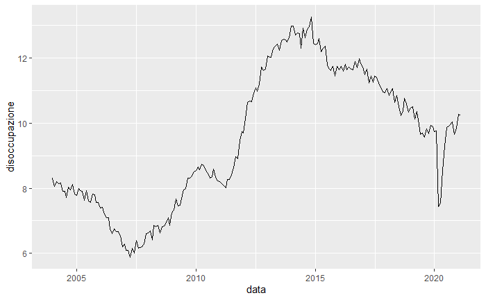

```r
## DA COMPLETARE
d_occupazione %>% filter(Sesso == "tutti") %>%
  ggplot(aes(x = data, y = disoccupazione)) + geom_line()
```

Mostrare l’andamento del tasso di disoccupazione nel corso degli anni per Maschi e Femmine.

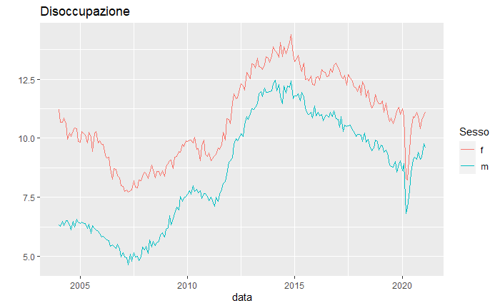

```r
## DA COMPLETARE
d_occupazione %>% filter(Sesso!="tutti") %>%
  ggplot(aes(x=data, y = disoccupazione, color = Sesso)) +
  geom_line() +
  ggtitle("Disoccupazione") +
  ylab("")
```

Mostrare il tasso di occupazione di Maschi e Femmine.

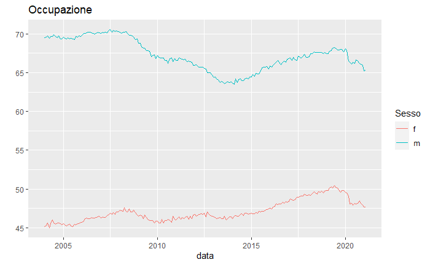

```r
## DA COMPLETARE
d_occupazione %>% filter(Sesso != "tutti") %>%
  ggplot(aes(x = data, y = occupazione, color = Sesso)) +
  geom_line() +
  ggtitle("Occupazione") +
  ylab("")
```

Mostrare il tasso di disoccupazione giovanile (c’è solo per Tutti e non diviso per sesso).

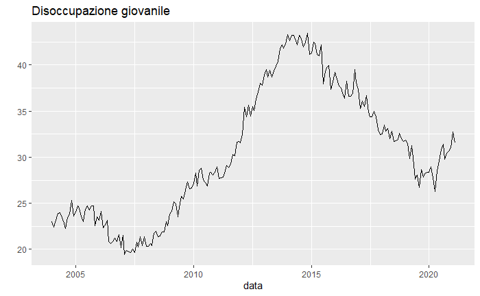

```r
## DA COMPLETARE
d_occupazione %>% filter(Sesso == "tutti") %>%
  ggplot(aes(x = data, y = disoccupazione.giovani)) +
  geom_line() +
  ggtitle("Disoccupazione giovanile") +
  ylab("")
```

Mostrare la media per ciasun anno del tasso di occupazione di Maschi e Femmine.

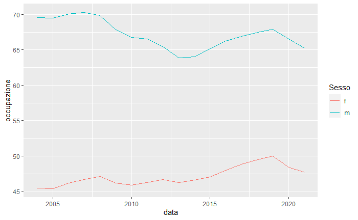

```r
## DA COMPLETARE
d_occupazione %>% filter(Sesso != "tutti") %>%
  group_by(Sesso, anno) %>%
  summarise(occupazione = mean(occupazione), data = first(data), .groups = "drop") %>%
  ggplot(aes(x = data, y = occupazione, color = Sesso)) +
  geom_line()
```

```r
## .groups = "drop" scarta i raggruppamenti fatti prima
```

Mostrare il tasso di disoccupazione (per Tutti, maschi+femmine) dei diversi anni in funzione del mese, in ascissa i mesi, ed in ordinata il tasso di disoccupazione. Il grafico deve mostrare tante linee, una per ogni anno presente nei dati.

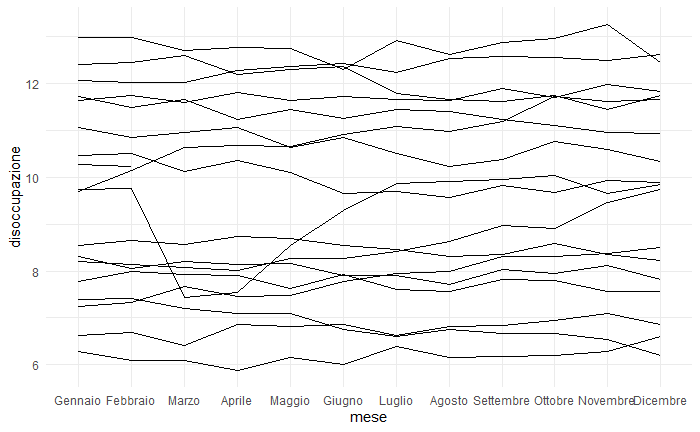

```r
## DA COMPLETARE
d_occupazione %>% filter(Sesso == "tutti") %>%
  ggplot(aes(x = mese, y = disoccupazione, group = anno)) +
  geom_line() +
  theme_minimal()
```

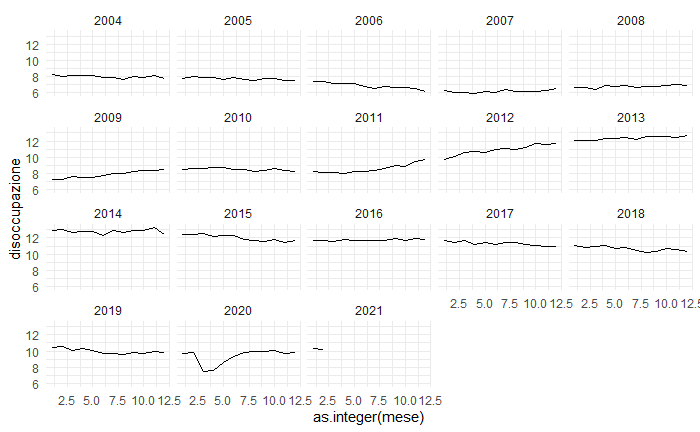

```r
## DA COMPLETARE
d_occupazione %>% filter(Sesso == "tutti") %>%
  ggplot(aes(x = as.integer(mese), y = disoccupazione, group = anno)) +
  geom_line() +
  facet_wrap(~anno)+
  theme_minimal()
```

#### Osservazione

A volte è utile riportare tanti andamenti ma evidenziarne uno in particolare con un colore diverso.

- è possibile utilizzare una variabile booleana `TRUE` per la serie da evidenziare e `FALSE` altrimenti, da mappare sull’estetica `color` (ed eventualmente size)
- per scegliere i colori (diversi dalla scala automatica) è possibile utilizzare la funzione `scale_color_manual()` che accetta il parametro `values` a cui passare l’elenco dei nomi dei colori, es. `scale_color_manual(values=c("gray70","red"))`; il primo valore corrisponde al caso `FALSE` mentre il secondo al `TRUE`

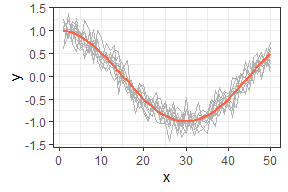

```r
x = 1:50
y = cos(x/30*pi) ## i valori di base sono un pezzo di coseno
ds = data.frame(
  cat = rep(c("Orig",1:9),each=50),   # originale + 10 repliche
  x = rep(x,10),                      # replica 10 volte la x
  y = c(y,rep(y,9)+rnorm(9*50,0,0.2)) # y e 9 repliche con valori casuali
)
ggplot(ds,aes(x=x,y=y,col=cat=="Orig",size=cat=="Orig",group=cat))+
  geom_line()+
  scale_size_manual(values=c(0.2,1),guide="none")+
  scale_color_manual(values=c("grey70","tomato"),guide="none")+
  theme_bw()
```

Modificare il grafico precedente in modo da evidenziare con un colore diverso i dati relativi all’anno 2020.

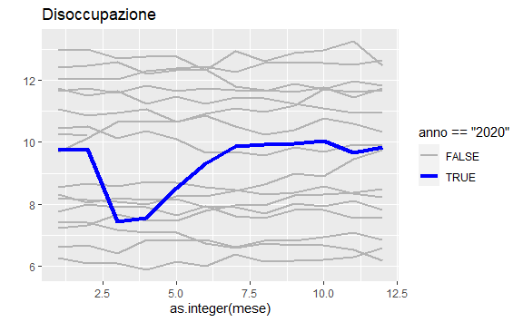

```r
## DA COMPLETARE
d_occupazione %>% filter(Sesso == "tutti") %>%
  ggplot(aes(x = as.integer(mese), y = disoccupazione, col=anno=="2020", size=anno=="2020", group = anno)) +
  geom_line() +
  scale_size_manual(values = c(1,1.5)) +
  scale_color_manual(values = c("grey70", "blue")) +
  ggtitle("Disoccupazione") +
  ylab("")
```

```r
NA
```

Mostrare il confronto della distribuzione del tasso di attività di Maschi e Femmine tramite un boxplot.

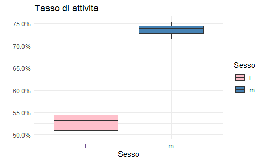

```r
## DA COMPLETARE
d_occupazione %>% filter(Sesso != "tutti") %>%
  ggplot(aes(x = Sesso, y = attivita/100, fill = Sesso)) +
  ggtitle("Tasso di attivita") +
  ylab("") +
  scale_y_continuous(labels = scales::percent_format()) +
  scale_fill_manual(values = c("pink", "steelblue")) +
  geom_boxplot() +
  theme_minimal()
```